# PA1_template

Tuomas Hjelt

26.7.2018

# Course Project 1

## Load the data and convert date column to proper type

Loads the needed libraries.

```r
library(dplyr)
library(ggplot2)
```

Reads the csv file to a variable while filtering out missing steps-values and converting date-column to proper type.

```r
data_no_na <- read.csv("activity.csv", header = TRUE, sep = ",") %>%
        filter(!is.na(steps)) %>%
        mutate(date = as.Date(as.character(date), format = "%Y-%m-%d"))
```

## What is mean total number of steps taken per day?

Summarizes total steps per date and assigns it to a variable.

```r
stepsperday <- data_no_na %>%
      group_by(date) %>%
      summarize(total_steps = sum(steps))
```

Draws a histogram of total number of steps per day.

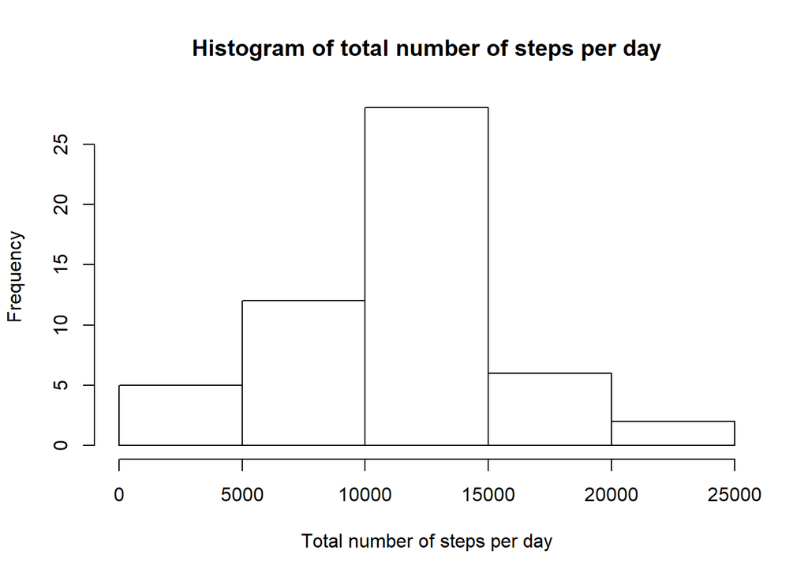

```r
hist(stepsperday$total_steps, main="Histogram of total number of steps per day",
     xlab="Total number of steps per day")
```

Calculates the mean and median of total steps per day.

```r
mean(stepsperday$total_steps)
```

```
## [1] 10766.19
```

```r
median(stepsperday$total_steps)
```

```
## [1] 10765
```

## What is the average daily activity pattern?

Summarizes the mean of steps per interval.

```r
average_steps <- data_no_na %>%
      group_by(interval) %>%
      summarize(avg_steps = mean(steps))
```

Draws a time series plot of average number of steps per interval.

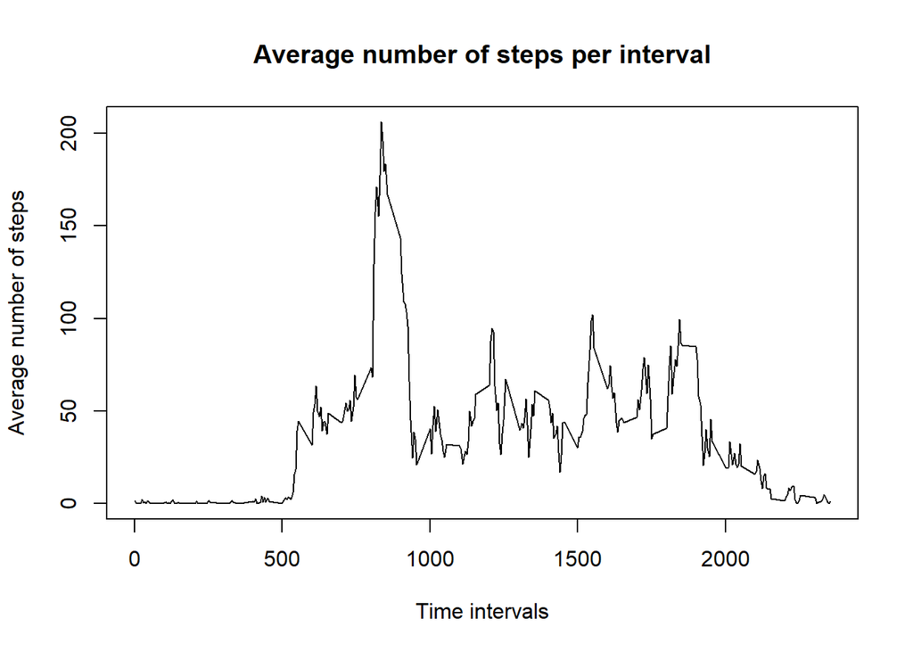

```r
plot(average_steps$interval, average_steps$avg_steps, type = "l", main = "Average number of steps per interval",
      xlab = "Time intervals", ylab = "Average number of steps")
```

Finds the 5-minute interval that contains the maximum number of steps.

```r
average_steps %>%
      filter(avg_steps == max(average_steps$avg_steps)) %>%
      select(interval)
```

```
## # A tibble: 1 x 1
##   interval
##      <int>
## 1      835
```

## Imputing missing values

Reads the data with missing values.

```r
data <- read.csv("activity.csv", header = TRUE, sep = ",") %>%
  mutate(date = as.Date(as.character(date), format = "%Y-%m-%d"))
```

Counts the total number of missing values.

```r
data %>% filter(is.na(steps)) %>% summarize(total_missing_rows = n())
```

```
##   total_missing_rows
## 1               2304
```

### Replace the missing NA values with the average steps in that interval across all the days

I decided to replace the missing NA values with the average steps in that interval across all the days. First I summarized the average steps per interval into a new variable.

```r
stepsperinterval <- data_no_na %>%
  group_by(interval) %>%
  summarize(avg_steps = mean(steps))
```

Copies the original dataset and loops through it. When it finds a missing value it gets the average step count according to the right interval from the just created dataset.

```r
data_imputed <- data
for (i in 1:nrow(data_imputed))
{
  if(is.na(data_imputed$steps[i]))
  {
    imp_value <- stepsperinterval$avg_steps[which(stepsperinterval$interval == data_imputed$interval[i])]
    data_imputed$steps[i] <- imp_value
  }
}
```

Summarizes the imputed date by calculating the sum of steps per date.

```r
stepsperday_imputed <- data_imputed %>%
  group_by(date) %>%
  summarize(total_steps = sum(steps))
```

DraWs a histogram of total number of steps per day with the imputed data.

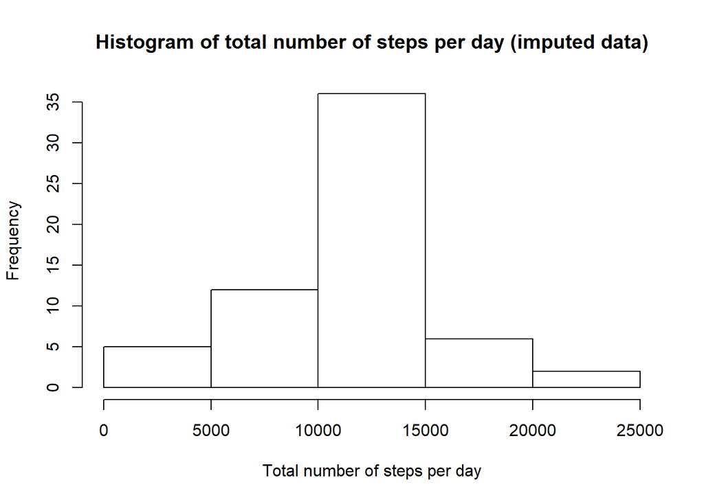

```r
hist(stepsperday_imputed$total_steps, main="Histogram of total number of steps per day (imputed data)",
     xlab="Total number of steps per day")
```

## Are there differences in activity patterns between weekdays and weekends?

Creates a function to separate weekdays and weekends. (my locale is Finnish so days are also in Finnish)

```r
weekday_part <- function(date_val) {
  x <- weekdays(date_val)
  if (x == "lauantai" || x == "sunnuntai") {
    ret_val <- "Weekend"
  }
  else {
    ret_val <- "Weekday"
  }
  ret_val
}
```

Uses sapply to loop through the dates and assigns a new column for the day type. Then summarizes the average steps per interval and day type.

```r
data_imputed$day_type <- as.factor(sapply(data_imputed$date, weekday_part))
stepsperday_imputed_wk <- data_imputed %>% group_by(interval, day_type) %>% summarize(avg_steps = mean(steps))
```

Draws two graphs to find differences between weekdays and weekends.

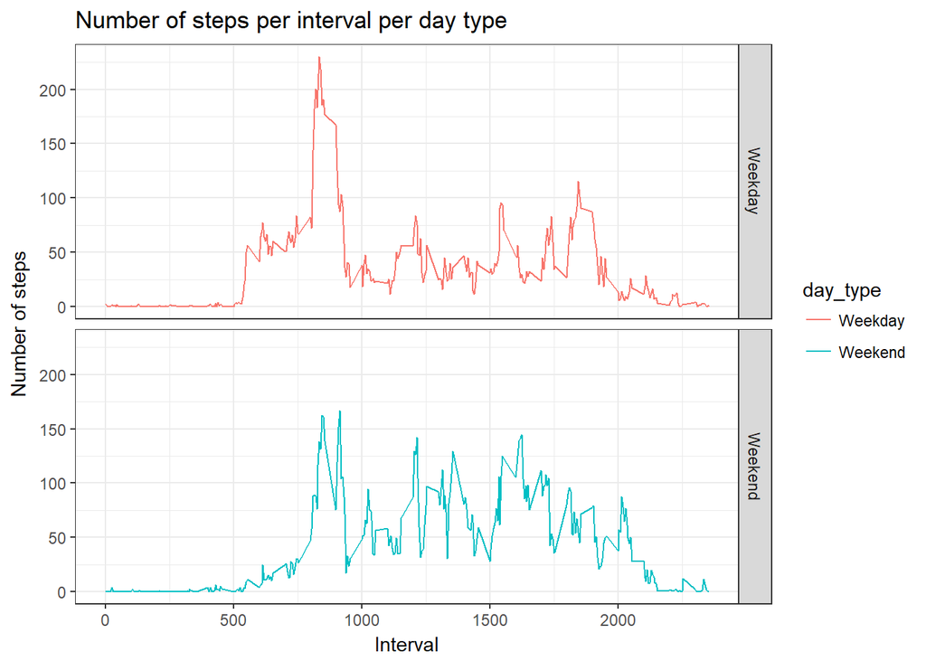

```r
p <- ggplot(stepsperday_imputed_wk, aes(interval,avg_steps)) +
  geom_line(stat = "identity", aes(colour = day_type)) +
  theme_bw() +
  facet_grid(day_type ~ .) +
  labs(x = "Interval", y = "Number of steps") +
  ggtitle("Number of steps per interval per day type")
print(p)
```

There seems to be some variation between them, especially during the mornings where more steps are been taken on weekdays.